# 28_Imbalanced

**Learning from Imbalanced Data**

By Prof. Seungchul Lee  
http://iai.postech.ac.kr/  
Industrial AI Lab at POSTECH

Source

- Slides by Piyush Rai

Table of Contents

# 1. Imbalanced Data

- Consider binary classification
- Often the classes are highly imbalanced

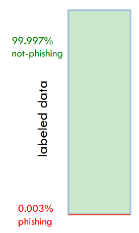

- Should I feel happy if the classifier gets 99.997% classification accuracy on test data?

## 1.1. True Definition of Imbalance Data?

- Debatable ...
- Scenario 1: 100,000 negative and 1,000 positive examples
- Scenario 2: 10,000 negative and 10 positive examples
- Scenario 3: 1,000 negative and 1 positive examples
- Usually, imbalance is characterized by absolute rather than relative rarity
  - Finding needles in a haystack...

## 1.2. Minimizing Loss

- Any model to minimize the loss, e.g.,

$$ \text{Classification}: \hat\omega = \arg \min_{\omega} \sum_{n=1}^{N} \ell \left(y_n,\omega^T x_n \right) $$

$\quad \;$ ... will usually get a high accuracy

- However, it will be highly biased towards predicting the majority class
  - Thus accuary alone cannot be trusted as the evaluation measure if we care more about predicting minority class (say positive) correctly

## 1.3. Better Evaluation Measures

- Precision: What fraction of positive predictions is truely positive

$$ P = \frac{\# \text{ example correctly predicted as positive}}{\# \text{ examples predicted as positive}}$$

- Recall: What fraction of total positives are predicted as positives

$$ R = \frac{\# \text{ example correctly predicted as positive}}{\# \text{ total positive examples in the test set}}$$

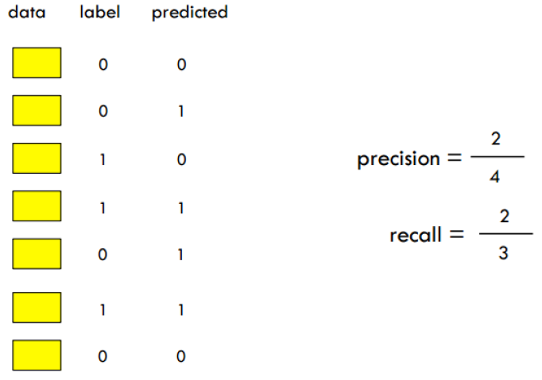

- Often there is a trade-off between precision and recall. Also there can be combined to yield other measures such as F1 score, AUC score, etc.

## 1.4. Dealing with Class Imbalance

- Modifying the training data (the class distiribution)
  - Undersampling the majority class
  - Oversampling the minority class
  - Reweighting the examples
- Modifying the learning model
  - Use loss functions customized to handle class imbalance
- Reweighting can be also seen as a way to modify the loss function

# 2. Modifying the Training Data

## 2.1. Undersampling

Create a new training data set by:

- including all $k$ "positive" examples
- randomly picking $k$ "negative" examples

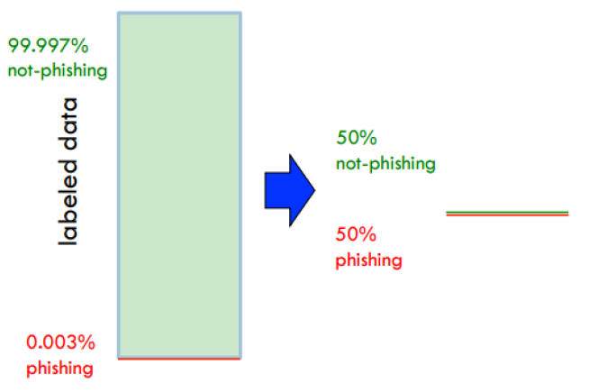

Throws away a lot of data/information, but efficient to train

## 2.2. Oversampling

Create a new training data set by:

- including all $m$ "negative" examples
- includ $m$ "positive" examples:
  - repeat each example a fixed number of times, or
  - sample with replacement

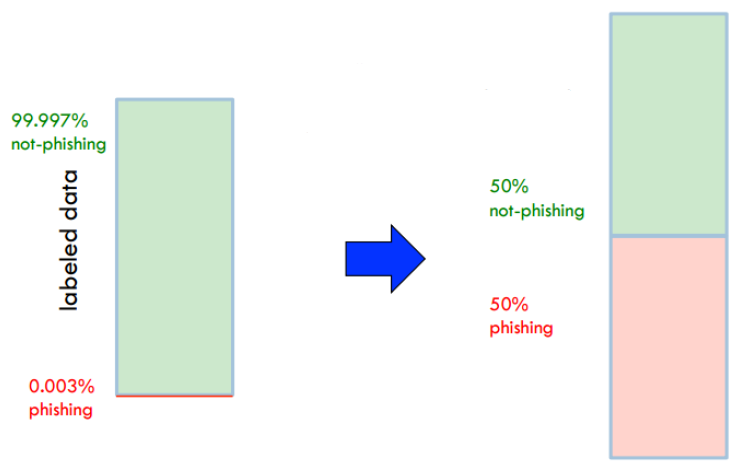

- From the loss function's perspective, the repeated examples simply constribute multiple times to the loss function
- Oversampling ususally tends to outperform undersampling because we are using more data to train the model
- Some oversampling methods (SMOTE) are based on creating synthetic examples from the minority class

## 2.3. Reweighting Examples

Add costs/weights to the training set

- "negative" examples get weight 1
- "positive" examples get a much larger weight

Change learning algorithm to optimize weighted training error

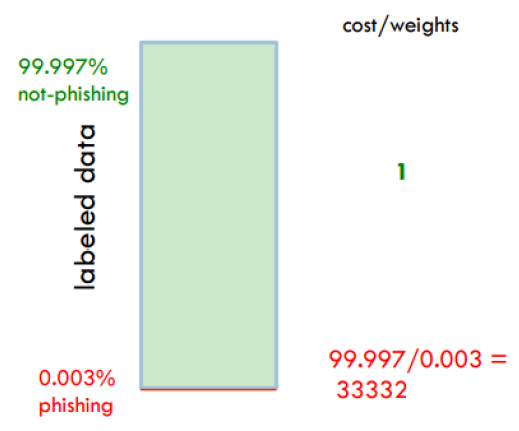

- Similar effect as oversampling but is more efficient (because there is no multiplicity of examples)
- Also requires a classfier that can learn with weighted examples

# 3. Modifying the Loss Function

## 3.1. Loss Functions Customized for Imbalanced Data

- Traditional loss functions have the form $\sum_{n=1}^{N} \ell \left( y_n, f(x_n)\right)$
- Such loss functions look at positive and negative examples individually, so the majority class tends to overwhelm the minority class
- Reweighting the loss function differently for different classes can be one way to handle class imbalance, e.g., $\sum_{n=1}^{N} C_{y_n} \ell \left( y_n, f(x_n)\right)$
- Alternatively, we can loss functions that look at pairs of examples (a positive example $x_n^+$ and a negative example $x_m^-$). For example:

$$ \ell \left( f(x_n^+), f(x_m^-)\right) = \begin{cases} 0, & \text{if }\; f(x_n^+) > f(x_m^{-})\\ 1, & \text{otherwise} \end{cases} $$

- These are called "pairwise" loss functions
- Why is it a good loss function for imbalanced data?

## 3.2. Pairwise Loss Functions

```python
%%javascript
$.getScript('https://kmahelona.github.io/ipython_notebook_goodies/ipython_notebook_toc.js')
```